# Lab 8 - things that can go wrong

Ilaria Prosdocimi

# Body fat

Prendiamo in esame il dataset `bodyfat` che abbiamo già usato in un esercizio. Leggiamo i dati e trasformiamo altezzae e peso dalle misure imperiali (libbre e pollici) a misure decimali (Kg e cm).

```r
# urlLocation <- "https://dasl.datadescription.com/download/data/3079"
# bodyfat <- read.table(urlLocation, header=TRUE)
bodyfat <- read.csv("bodyfat.csv",header = TRUE)
bodyfat$Height <- bodyfat$Height * 2.54
bodyfat$Weight <- bodyfat$Weight / 2.205
#plot(bodyfat)
```

Una descrizione completa del dataset è disponibile [qui](http://jse.amstat.org/datasets/fat.txt); le variabili contenute nel dataset sono:

- Density: Percent body fat using Brozek’s equation, 457/Density - 414.2
- Pct.BF: Percent body fat using Siri’s equation, 495/Density - 450
- Age: Age (yrs)
- Weight: Weight (lbs)
- Height: Height (inches)
- Neck: Neck circumference (cm)
- Chest Chest circumference (cm)
- Abdomen/Waist: Abdomen circumference (cm) “at the umbilicus and level with the iliac crest”
- Hip: Hip circumference (cm)
- Thigh: Thigh circumference (cm)
- Knee: Knee circumference (cm)
- Ankle: Ankle circumference (cm)
- Bicep: Extended biceps circumference (cm)
- Forearm: Forearm circumference (cm)
- Wrist: Wrist circumference (cm) “distal to the styloid processes”

Si desidera costruire un modello per predire la percentuale di materia grassa di un individuo a partire dalle altre variabili. Possiamo iniziare con un modello che contenga tutti le variabili contenute nel dataset come predittori (tranne `Density`):

```r
## remove density
fit_all <- lm(Pct.BF~., data = bodyfat[,-1])
summary(fit_all)
```

```
##
## Call:
## lm(formula = Pct.BF ~ ., data = bodyfat[, -1])
##
## Residuals:
##      Min       1Q   Median       3Q      Max
## -10.9900  -3.1244  -0.1674   3.0248   9.8648
##
## Coefficients: (1 not defined because of singularities)
##             Estimate Std. Error t value Pr(>|t|)
## (Intercept)  1.68516   23.37412   0.072 0.942587
## Age          0.07189    0.03217   2.234 0.026389 *
## Weight      -0.03886    0.14804  -0.263 0.793153
## Height      -0.09715    0.07525  -1.291 0.197989
## Neck        -0.38682    0.23486  -1.647 0.100887
## Chest       -0.11919    0.10825  -1.101 0.272004
## Abdomen      0.90452    0.09140   9.897  < 2e-16 ***
## Waist             NA         NA      NA       NA
## Hip         -0.15878    0.14586  -1.089 0.277446
## Thigh        0.17299    0.14683   1.178 0.239926
## Knee        -0.04580    0.24560  -0.186 0.852230
## Ankle        0.18502    0.21985   0.842 0.400862
## Bicep        0.17968    0.17039   1.054 0.292732
## Forearm      0.27605    0.20692   1.334 0.183454
## Wrist       -1.80162    0.53304  -3.380 0.000848 ***
## ---
## Signif. codes:  0 '***' 0.001 '**' 0.01 '*' 0.05 '.' 0.1 ' ' 1
##
## Residual standard error: 4.255 on 236 degrees of freedom
## Multiple R-squared:  0.7505, Adjusted R-squared:  0.7368
## F-statistic: 54.61 on 13 and 236 DF,  p-value: < 2.2e-16
```

`Waist` e `Abdomen` sono perfettaemnte co-lienari, non è possibile stiamre l’effetto di entrambe le variabili nel modello:

```r
summary(lm(Pct.BF~Abdomen, data = bodyfat[,-1]))
```

```
##
## Call:
## lm(formula = Pct.BF ~ Abdomen, data = bodyfat[, -1])
##
## Residuals:
##      Min       1Q   Median       3Q      Max
## -10.8987  -3.6453   0.1864   3.1775  12.7887
##
## Coefficients:
##              Estimate Std. Error t value Pr(>|t|)
## (Intercept) -42.73413    2.71651  -15.73   <2e-16 ***
## Abdomen       0.66928    0.02926   22.88   <2e-16 ***
## ---
## Signif. codes:  0 '***' 0.001 '**' 0.01 '*' 0.05 '.' 0.1 ' ' 1
##
## Residual standard error: 4.713 on 248 degrees of freedom
## Multiple R-squared:  0.6785, Adjusted R-squared:  0.6772
## F-statistic: 523.3 on 1 and 248 DF,  p-value: < 2.2e-16
```

```r
summary(lm(Pct.BF~Waist, data = bodyfat[,-1]))
```

```
##
## Call:
## lm(formula = Pct.BF ~ Waist, data = bodyfat[, -1])
##
## Residuals:
##      Min       1Q   Median       3Q      Max
## -10.8987  -3.6453   0.1864   3.1775  12.7887
##
## Coefficients:
##              Estimate Std. Error t value Pr(>|t|)
## (Intercept) -42.73413    2.71651  -15.73   <2e-16 ***
## Waist         1.69997    0.07431   22.88   <2e-16 ***
## ---
## Signif. codes:  0 '***' 0.001 '**' 0.01 '*' 0.05 '.' 0.1 ' ' 1
##
## Residual standard error: 4.713 on 248 degrees of freedom
## Multiple R-squared:  0.6785, Adjusted R-squared:  0.6772
## F-statistic: 523.3 on 1 and 248 DF,  p-value: < 2.2e-16
```

```r
cor(bodyfat$Waist, bodyfat$Abdomen)
```

```
## [1] 1
```

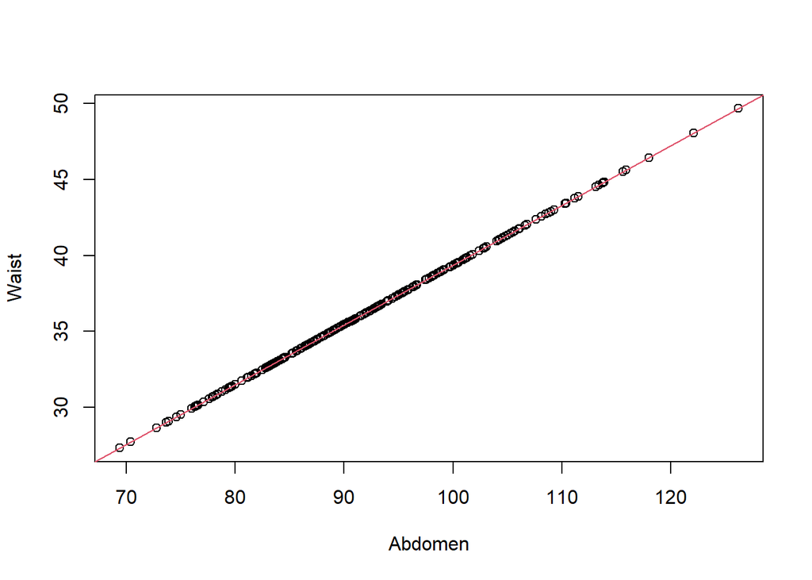

```r
plot(Waist~Abdomen, data = bodyfat); abline(lm(Waist~Abdomen, data = bodyfat), col = 2)
```

```r
## remove density and abdomen
fit_all <- lm(Pct.BF~., data = bodyfat[,-which(names(bodyfat) %in% c("Density", "Abdomen"))])
summary(fit_all)
```

```
##
## Call:
## lm(formula = Pct.BF ~ ., data = bodyfat[, -which(names(bodyfat) %in%
##     c("Density", "Abdomen"))])
##
## Residuals:
##      Min       1Q   Median       3Q      Max
## -10.9900  -3.1244  -0.1674   3.0248   9.8648
##
## Coefficients:
##             Estimate Std. Error t value Pr(>|t|)
## (Intercept)  1.68516   23.37412   0.072 0.942587
## Age          0.07189    0.03217   2.234 0.026389 *
## Weight      -0.03886    0.14804  -0.263 0.793153
## Height      -0.09715    0.07525  -1.291 0.197989
## Neck        -0.38682    0.23486  -1.647 0.100887
## Chest       -0.11919    0.10825  -1.101 0.272004
## Waist        2.29748    0.23215   9.897  < 2e-16 ***
## Hip         -0.15878    0.14586  -1.089 0.277446
## Thigh        0.17299    0.14683   1.178 0.239926
## Knee        -0.04580    0.24560  -0.186 0.852230
## Ankle        0.18502    0.21985   0.842 0.400862
## Bicep        0.17968    0.17039   1.054 0.292733
## Forearm      0.27605    0.20692   1.334 0.183454
## Wrist       -1.80162    0.53304  -3.380 0.000848 ***
## ---
## Signif. codes:  0 '***' 0.001 '**' 0.01 '*' 0.05 '.' 0.1 ' ' 1
##
## Residual standard error: 4.255 on 236 degrees of freedom
## Multiple R-squared:  0.7505, Adjusted R-squared:  0.7368
## F-statistic: 54.61 on 13 and 236 DF,  p-value: < 2.2e-16
```

In modello è significativo contro il modello nullo (il p-value per la statistica F è basso) ma solo alcuni dei predittori risultano essere significativi, e alcune stime hanno un segno che indica una relazione opposta a quella che ci si potrebbe aspettare e che si trova quando si stima la relazione tra il singolo predittore e la variabile risposta:

```r
coef(lm(Pct.BF~Chest, data = bodyfat))
```

```
## (Intercept)       Chest
## -52.7122498   0.7127203
```

```r
coef(fit_all)["Chest"]
```

```
##      Chest
## -0.1191888
```

Guardiamo per esempio alle relazioni bivariate tra $X_j$ e $Y$

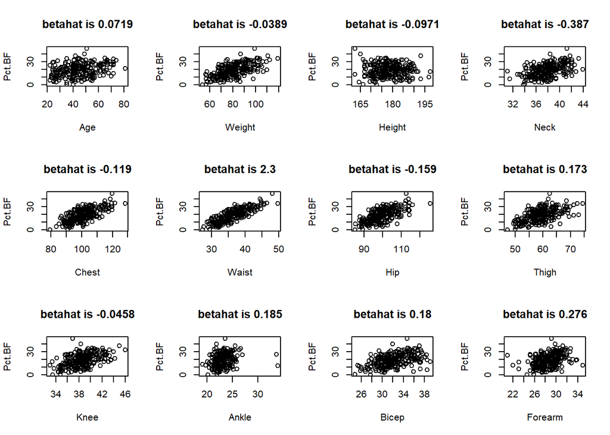

```r
par(mfrow= c(3,4))
for(j in 2:13){
  plot(bodyfat[,-which(names(bodyfat) %in% c("Density", "Abdomen"))][,c(j,1)])
  title(main = paste("betahat is", signif(coef(fit_all)[j],3)))
}
```

Vediamo delle relazioni piuttosto forti tra i predittori ed $Y$ anche se alcuni predittori risultano non significativi. Inoltre la direzione della relazione stimata non sempre è quella che si vede nella relazione bivariate (questo ha senso perché la stima che si ottiene nei modelli lineari multipli per una variabile è l’effetto che ha $X_j$ su $Y$ *considerato l’effetto degli altri predittori su $Y$*). Cosa succede? Le variabili esplicative sono fortemente correlate tra loro:

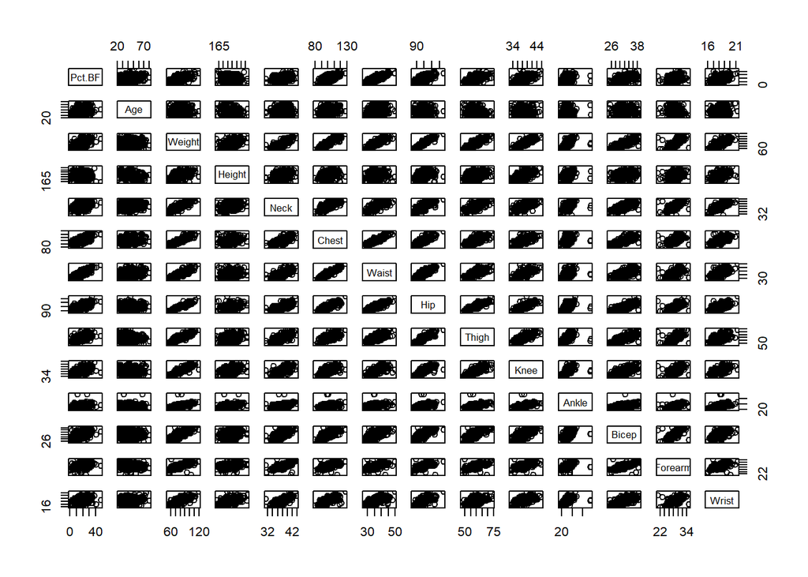

```r
plot(bodyfat[,-which(names(bodyfat) %in% c("Density", "Abdomen"))])
```

```r
signif(cor(bodyfat),4)
```

```
##          Density   Pct.BF      Age   Weight   Height    Neck   Chest Abdomen
## Density  1.00000 -0.98750 -0.28090 -0.59840  0.04342 -0.4705 -0.6803 -0.8090
## Pct.BF  -0.98750  1.00000  0.29510  0.61730 -0.02939  0.4885  0.7007  0.8237
## Age     -0.28090  0.29510  1.00000 -0.01605 -0.24590  0.1187  0.1818  0.2428
## Weight  -0.59840  0.61730 -0.01605  1.00000  0.51290  0.8100  0.8913  0.8737
## Height   0.04342 -0.02939 -0.24590  0.51290  1.00000  0.3247  0.2236  0.1867
## Neck    -0.47050  0.48850  0.11870  0.81000  0.32470  1.0000  0.7688  0.7285
## Chest   -0.68030  0.70070  0.18180  0.89130  0.22360  0.7688  1.0000  0.9101
## Abdomen -0.80900  0.82370  0.24280  0.87370  0.18670  0.7285  0.9101  1.0000
## Waist   -0.80900  0.82370  0.24280  0.87370  0.18670  0.7285  0.9101  1.0000
## Hip     -0.61640  0.63270 -0.05813  0.93270  0.39670  0.7075  0.8249  0.8605
## Thigh   -0.54280  0.54850 -0.21610  0.85210  0.34960  0.6688  0.7076  0.7370
## Knee    -0.47890  0.49230  0.01719  0.84270  0.51290  0.6482  0.6976  0.7104
## Ankle   -0.24430  0.24460 -0.10960  0.58090  0.39450  0.4344  0.4471  0.4075
## Bicep   -0.47580  0.48150 -0.04414  0.78520  0.31860  0.7085  0.7069  0.6563
## Forearm -0.35460  0.36470 -0.08512  0.68330  0.32200  0.6608  0.5994  0.5301
## Wrist   -0.31780  0.33900  0.21750  0.72510  0.39700  0.7312  0.6445  0.6023
##           Waist      Hip   Thigh     Knee   Ankle    Bicep  Forearm   Wrist
## Density -0.8090 -0.61640 -0.5428 -0.47890 -0.2443 -0.47580 -0.35460 -0.3178
## Pct.BF   0.8237  0.63270  0.5485  0.49230  0.2446  0.48150  0.36470  0.3390
## Age      0.2428 -0.05813 -0.2161  0.01719 -0.1096 -0.04414 -0.08512  0.2175
## Weight   0.8737  0.93270  0.8521  0.84270  0.5809  0.78520  0.68330  0.7251
## Height   0.1867  0.39670  0.3496  0.51290  0.3945  0.31860  0.32200  0.3970
## Neck     0.7285  0.70750  0.6688  0.64820  0.4344  0.70850  0.66080  0.7312
## Chest    0.9101  0.82490  0.7076  0.69760  0.4471  0.70690  0.59940  0.6445
## Abdomen  1.0000  0.86050  0.7370  0.71040  0.4075  0.65630  0.53010  0.6023
## Waist    1.0000  0.86050  0.7370  0.71040  0.4075  0.65630  0.53010  0.6023
## Hip      0.8605  1.00000  0.8811  0.80920  0.5212  0.72160  0.60330  0.6264
## Thigh    0.7370  0.88110  1.0000  0.77750  0.5036  0.74400  0.60430  0.5437
## Knee     0.7104  0.80920  0.7775  1.00000  0.5852  0.65420  0.57860  0.6557
## Ankle    0.4075  0.52120  0.5036  0.58520  1.0000  0.44900  0.42940  0.5450
## Bicep    0.6563  0.72160  0.7440  0.65420  0.4490  1.00000  0.70110  0.6137
## Forearm  0.5301  0.60330  0.6043  0.57860  0.4294  0.70110  1.00000  0.5983
## Wrist    0.6023  0.62640  0.5437  0.65570  0.5450  0.61370  0.59830  1.0000
```

Le diverse variabili esplicative stanno ‘’rubando’’ capacità predittiva le une: abbiamo un problema di multi-colinearità.

In realtà questo può già succedere anche con modelli meno complessi, per esempio se prendessimo in considerazione solo `Weight` e `Hip` come variabili esplicative:

```r
summary(lm(Pct.BF~Weight, data = bodyfat))$coef
```

```
##                Estimate Std. Error   t value     Pr(>|t|)
## (Intercept) -14.6931445 2.76045092 -5.322733 2.287854e-07
## Weight        0.4175748 0.03379383 12.356542 1.189995e-27
```

```r
summary(lm(Pct.BF~Hip, data = bodyfat))$coef
```

```
##                Estimate Std. Error   t value     Pr(>|t|)
## (Intercept) -62.1198282 6.32073463 -9.827944 1.831577e-19
## Hip           0.8143548 0.06329692 12.865629 2.324857e-29
```

```r
summary(lm(Pct.BF~Weight+Hip, data = bodyfat))$coef
```

```
##                Estimate  Std. Error   t value     Pr(>|t|)
## (Intercept) -48.5239974 10.85559186 -4.469954 1.192747e-05
## Weight        0.1414897  0.09197618  1.538329 1.252481e-01
## Hip           0.5632488  0.17501293  3.218327 1.462004e-03
```

```r
cor(bodyfat$Weight, bodyfat$Hip)
```

```
## [1] 0.9326905
```

Includere una variabile esplicativa fortemente correlata ad un predittore già presente nel modello tipicamente riduce la significatività della relazione tra una o più delle variabili esplicative e la variabile risposta: questo avviene perché quando si inseriscono variabili correlate tra lor si *inflaziona* la variabilità delle stime dei coefficienti di regressione $\beta$.

Questo ha anche un impatto sulla variabilità della predizione della funzione di regressione:

```r
predict(lm(Pct.BF~Hip, data = bodyfat),newdata = data.frame(Hip = 110, Weight = 90), se.fit = TRUE)$se.fit
```

```
## [1] 0.7712153
```

```r
predict(lm(Pct.BF~Weight, data = bodyfat),newdata = data.frame(Hip = 110, Weight = 90), se.fit = TRUE)$se.fit
```

```
## [1] 0.5181005
```

```r
predict(lm(Pct.BF~Hip+Weight, data = bodyfat),newdata = data.frame(Hip = 110, Weight = 90), se.fit = TRUE)$se.fit
```

```
## [1] 1.138698
```

Vediamo anche che alcuni degli autovalori della matrice $(X^\top X)$ sono piccoli:

```r
X <- model.matrix(fit_all)
format(eigen(crossprod(X))$values,scientific = FALSE)
```

```
##  [1] "17789627.87058866" "   42722.10010394" "   31636.07409075"
##  [4] "    3663.20889556" "    2356.64007409" "    1258.03429797"
##  [7] "     621.21830950" "     523.42574882" "     441.77912137"
## [10] "     334.95188497" "     307.83287661" "     258.56063161"
## [13] "      62.58052038" "       0.03314237"
```

questo risulta in una difficoltà ad invertire $(X^\top X)$, la cui inversa tenderà ad avere valori grandi e ad “esplodere”. Quando si includono variabili correlate infatti si inflaziona la variabilità della stima. Possiamo quantificare di quanto aumenta la variabilità nell’aggiungere predittori aggiuntivi tramite il *Variance Inflation Factor* (VIF) per valutare se ci sono problematicità legate a multi-colinearità nel modello stimato. Possiamo usare la funzione `vif` nel pacchetto `car`:

```r
car::vif(fit_all)
```

```
##       Age    Weight    Height      Neck     Chest     Waist       Hip     Thigh
##  2.278191 45.298843  3.439587  3.978898 10.712505 11.967579 12.146249  7.153711
##      Knee     Ankle     Bicep   Forearm     Wrist
##  4.441752  1.810253  3.409524  2.422878  3.263677
```

```r
mean(car::vif(fit_all))
```

```
## [1] 8.640281
```

Questo indica quanto siano sovradimensionate le stime delle varianze per i parametri di regressione stimati $\beta_j$:

```r
diag(solve(t(X) %*% X))[2]*(sum((bodyfat$Age-mean(bodyfat$Age))^2))
```

```
##      Age
## 2.278191
```

```r
diag(solve(t(X) %*% X))[3]*(sum((bodyfat$Weight-mean(bodyfat$Weight))^2))
```

```
##   Weight
## 45.29884
```

```r
rm(X)
```

Un altro modo di interpretare il VIF è l’indicazione di quanto sia possibile stimare una delle variabili esplicative come una funzione delle altre variabili presenti nel dataset:

```r
1/(1-summary(lm(Age~ Weight+Height+Neck+Chest+Waist+Hip+Thigh+Knee+Ankle+Bicep+Forearm+Wrist, data =bodyfat))$r.squared)
```

```
## [1] 2.278191
```

```r
1/(1-summary(lm(Weight~ Age+Height+Neck+Chest+Waist+Hip+Thigh+Knee+Ankle+Bicep+Forearm+Wrist, data =bodyfat))$r.squared)
```

```
## [1] 45.29884
```

In questo modello è chiaro che ci sono alcune variabili che sono combinazioni lineari quasi perfette delle altre variabili: l’informazione è in un qualche modo ridondante. Proviamo a ridurre la complessità del modello e togliamo le variabili con VIF più alto (in alternativa/esercizio - si può usare una selezione stepwise per trovare un sottomodello opportuno):

```r
sort(car::vif(fit_all))
```

```
##     Ankle       Age   Forearm     Wrist     Bicep    Height      Neck      Knee
##  1.810253  2.278191  2.422878  3.263677  3.409524  3.439587  3.978898  4.441752
##     Thigh     Chest     Waist       Hip    Weight
##  7.153711 10.712505 11.967579 12.146249 45.298843
```

```r
fit_sub1 <- lm(Pct.BF ~ Age + Forearm+Wrist+Bicep+Height+Neck+Knee+Thigh, data = bodyfat)
anova(fit_sub1, fit_all) # The simpler model gives a worse goodness of fit
```

```
## Analysis of Variance Table
##
## Model 1: Pct.BF ~ Age + Forearm + Wrist + Bicep + Height + Neck + Knee +
##     Thigh
## Model 2: Pct.BF ~ Age + Weight + Height + Neck + Chest + Waist + Hip +
##     Thigh + Knee + Ankle + Bicep + Forearm + Wrist
##   Res.Df    RSS Df Sum of Sq      F    Pr(>F)
## 1    241 7979.2
## 2    236 4273.7  5    3705.4 40.923 < 2.2e-16 ***
## ---
## Signif. codes:  0 '***' 0.001 '**' 0.01 '*' 0.05 '.' 0.1 ' ' 1
```

```r
car::vif(fit_sub1); mean(car::vif(fit_sub1)) # but we still have multi-collinearity
```

```
##      Age  Forearm    Wrist    Bicep   Height     Neck     Knee    Thigh
## 1.654046 2.367286 2.854415 3.165032 1.669186 3.225747 3.909048 4.431717
```

```
## [1] 2.90956
```

```r
X <- model.matrix(fit_sub1)
eigen(crossprod(X))$values ## still problematic
```

```
## [1] 1.064518e+07 4.120727e+04 6.603562e+03 9.681392e+02 4.799507e+02
## [6] 3.643548e+02 3.063157e+02 7.119880e+01 2.677529e-01
```

```r
sort(car::vif(fit_sub1))
```

```
##      Age   Height  Forearm    Wrist    Bicep     Neck     Knee    Thigh
## 1.654046 1.669186 2.367286 2.854415 3.165032 3.225747 3.909048 4.431717
```

```r
fit_sub2 <- lm(Pct.BF ~ Age + Forearm, data = bodyfat)
summary(fit_sub2)
```

```
##
## Call:
## lm(formula = Pct.BF ~ Age + Forearm, data = bodyfat)
##
## Residuals:
##      Min       1Q   Median       3Q      Max
## -14.5633  -5.6459  -0.1085   4.7517  26.4490
##
## Coefficients:
##              Estimate Std. Error t value Pr(>|t|)
## (Intercept) -36.64694    6.87498  -5.330 2.21e-07 ***
## Age           0.21533    0.03649   5.901 1.19e-08 ***
## Forearm       1.60537    0.22759   7.054 1.74e-11 ***
## ---
## Signif. codes:  0 '***' 0.001 '**' 0.01 '*' 0.05 '.' 0.1 ' ' 1
##
## Residual standard error: 7.259 on 247 degrees of freedom
## Multiple R-squared:  0.2401, Adjusted R-squared:  0.234
## F-statistic: 39.03 on 2 and 247 DF,  p-value: 1.869e-15
```

```r
anova(fit_sub2, fit_sub1)
```

```
## Analysis of Variance Table
##
## Model 1: Pct.BF ~ Age + Forearm
## Model 2: Pct.BF ~ Age + Forearm + Wrist + Bicep + Height + Neck + Knee +
##     Thigh
##   Res.Df     RSS Df Sum of Sq      F    Pr(>F)
## 1    247 13015.8
## 2    241  7979.2  6    5036.6 25.354 < 2.2e-16 ***
## ---
## Signif. codes:  0 '***' 0.001 '**' 0.01 '*' 0.05 '.' 0.1 ' ' 1
```

```r
car::vif(fit_sub2); mean(car::vif(fit_sub2))
```

```
##      Age  Forearm
## 1.007298 1.007298
```

```
## [1] 1.007298
```

Il modello `fit_sub2` ha meno problemi legati a multi-colinearità, ma ha comunque un valore più grande di $\hat{\sigma}$ e un valore di $R^2$ abbastanza più basso.

Non facile bilanciare la necessità di ottenere modelli parsimoniosi, senza problemi legati a co-linearità ma precisi nella predizione.

Se il focus della nostra stima è la stima precisa dei parametri $\beta_j$ e dei loro errori la co-linearità è un problema che impatta la capactià di stima. Se invece ci interessa di più predirre “out-of-sample” la co-linearità può essere meno problematica, sebbene vada ad impattare la stima che possiamo fare della variabilità della stima.

## Bodyfat data: un secondo sguardo

Ci concentriamo ora su un sottoinsieme di variabili: `Weight`, `Forearm`, `Hip`, `Age` e `Ankle`

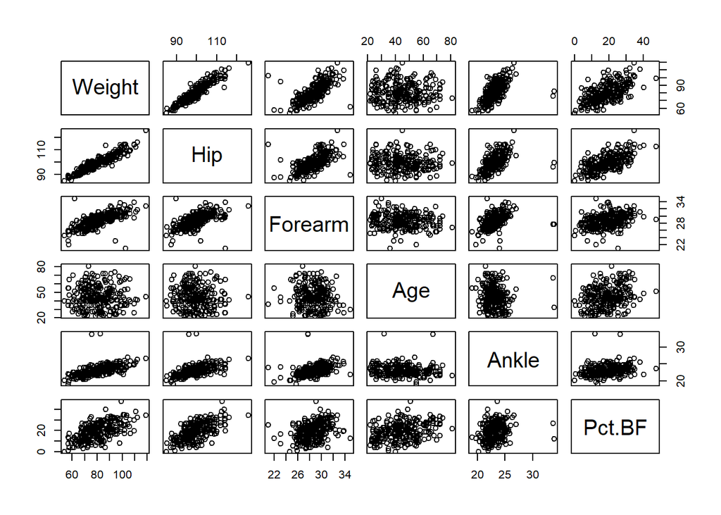

```r
plot(bodyfat[,c("Weight","Hip","Forearm","Age","Ankle","Pct.BF")])
```

Si nota immediatamente che per alcuni soggetti alcune delle variabili hanno valori molto diversi da quelli della maggior parte del campione: il caso più notevole sono due soggetti con caviglie particolarmente grandi:

```r
bodyfat[bodyfat$Ankle > 30,]
```

```
##    Density Pct.BF Age   Weight  Height Neck Chest Abdomen    Waist  Hip Thigh
## 31  1.0716   11.9  32 82.53968 187.325 38.7 100.5    88.7 34.92126 99.8  57.5
## 84  1.0386   26.6  67 75.73696 171.450 36.5  98.9    89.7 35.31496 96.2  54.7
##    Knee Ankle Bicep Forearm Wrist
## 31 38.7  33.9  32.5    27.7  18.4
## 84 37.8  33.7  32.4    27.7  18.2
```

Guardiamo qual è l’impatto della presenza di queste due osservazioni sul modello stimato:

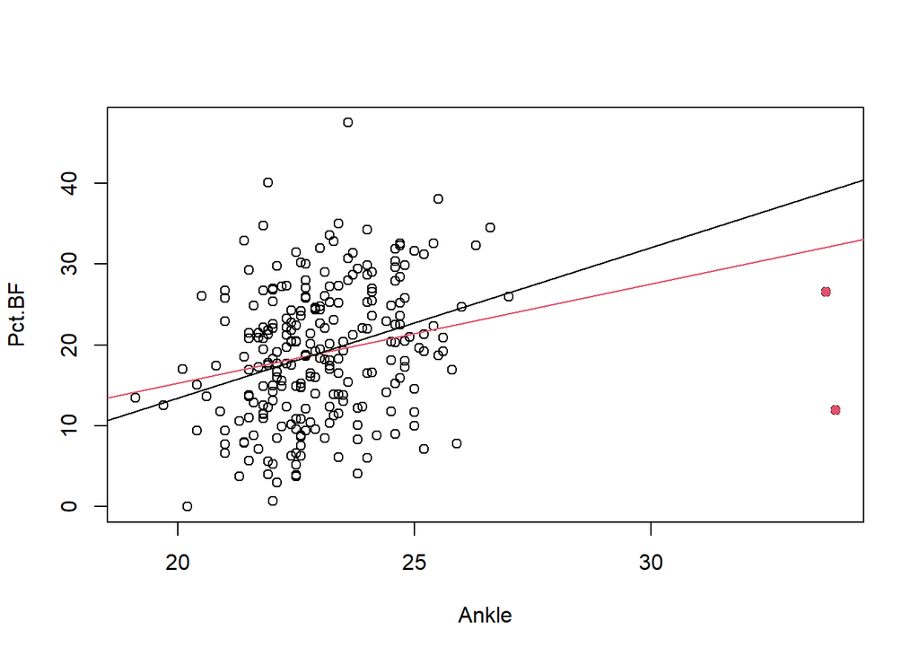

```r
plot(bodyfat[,c("Ankle","Pct.BF")])
points(bodyfat[bodyfat$Ankle > 30,c("Ankle","Pct.BF")], col = 2, pch = 16)
abline(coef(lm(Pct.BF~Ankle, data = bodyfat)), col = 2)
abline(coef(lm(Pct.BF~Ankle, data = bodyfat, subset = bodyfat$Ankle < 30)))
```

I due punti cambiano di molto la stima. Questo perché hanno un valore di *leverage* alto:

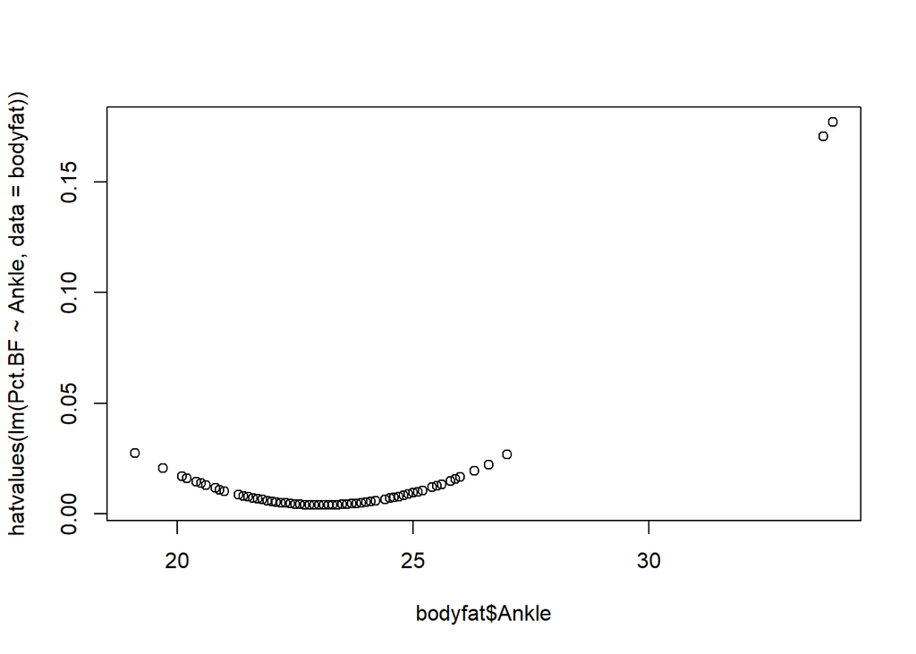

```r
plot(bodyfat$Ankle, hatvalues(lm(Pct.BF~Ankle, data = bodyfat)))
```

I due punti sono evidenti nel grafico che mostra il valore di leverage contro i residui e per uno dei due punti si nota anche un valore notevole del residuo standardizzato :

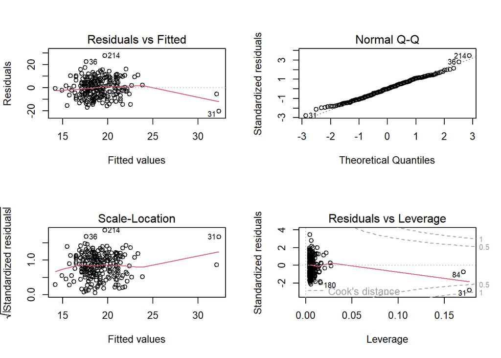

```r
par(mfrow=c(2,2))
plot(lm(Pct.BF~Ankle, data = bodyfat))
```

Concentriamoci per un attimo sulle quantità utili per individuare punti di leva e punti particolarmente influenti nella stima:

```r
fit_ankle <- lm(Pct.BF~Ankle, data = bodyfat)
X <- model.matrix(fit_ankle)
```

Il valore di *leverage* corrisponde alla diagonale della matrice cappello $H = X (X^{\top} X)^{-1}X^{\top}$:

```r
head(hatvalues(fit_ankle))
```

```
##           1           2           3           4           5           6
## 0.006032073 0.004156689 0.005264227 0.004110689 0.005264227 0.013407405
```

```r
head(diag(X %*% solve(crossprod(X)) %*% t(X)))
```

```
##           1           2           3           4           5           6
## 0.006032073 0.004156689 0.005264227 0.004110689 0.005264227 0.013407405
```

Questa misura è semplice da visualizzare per modelli semplici ma diventa complicata quando si stanno utilizzando modelli multipli in cui un punto può avere un valore di leverage alto anche quando non è “estremo” per nessuna delle distribuzioni marginali dei predittori ma è diverso dal comportamento del resto del campione:

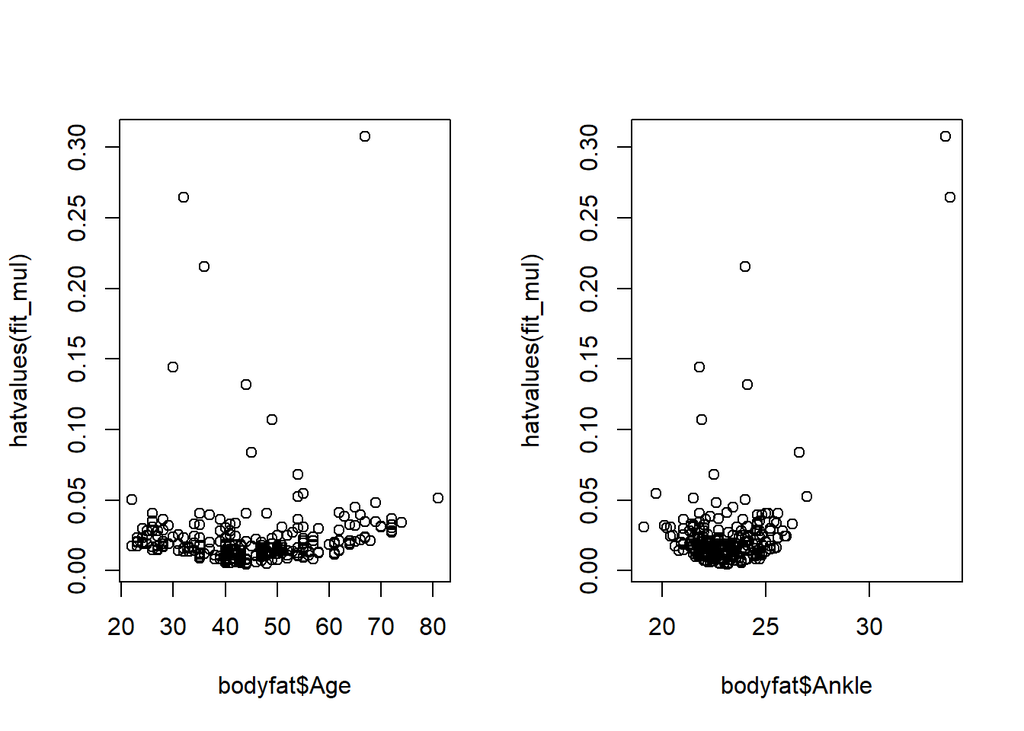

```r
fit_mul <- lm(Pct.BF~Ankle+Weight+Age+Forearm+Hip, data = bodyfat)
par(mfrow=c(1,2))
plot(bodyfat$Age, hatvalues(fit_mul))
plot(bodyfat$Ankle, hatvalues(fit_mul))
```

I soggetti con valori molto alti per `Ankle` hanno si un valore alto di leverage ma ci sono altre osservazioni che sembrano avere un valore alto. Si nota anche come il valore dei leverage sia minimo vicino al valore della media delle $X_j$. I punti con valori alti di leverage sono soggetti per cui si osservano valori non in linea con il resto del campione:

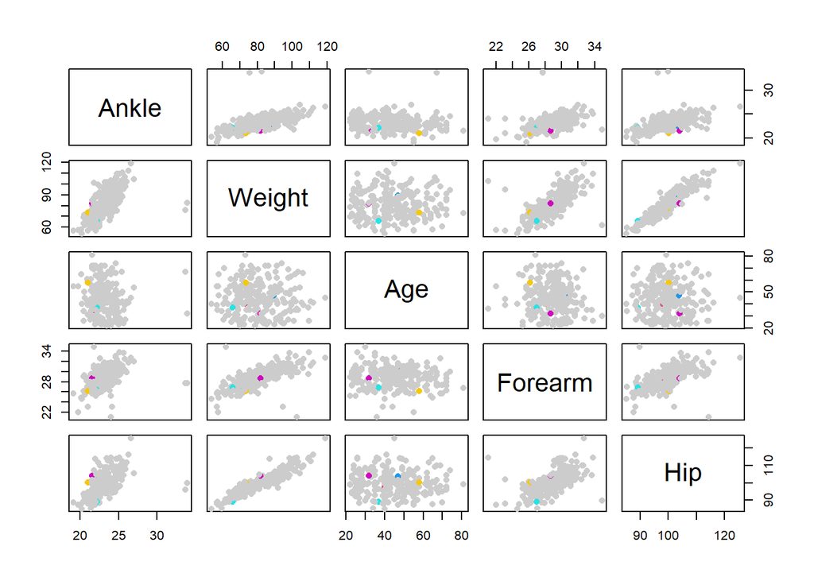

```r
## points iwith high leverage in color
cvec <- rep("grey80", nrow(bodyfat))
cvec[hatvalues(fit_mul)>0.1] <- c(2,3,4,5,6,7)
plot(bodyfat[order(hatvalues(fit_mul)),c("Ankle","Weight","Age","Forearm","Hip")], pch = 16,
     col = cvec)
```

Un altro modo per valutare l’impatto che ha ogni punto sulla stima è valutare quale è la varianza per ogni residuo, R permette di estrarre questa informazione con la funzione `influence`, che crea molte misure utili a valutare l’influenza dei singoli punti sulla stima. Inoltre possiamo usare `rstandard` e `rstudent` per estrarre i residui standardizzati e studentizzati:

```r
# ?influence
head(rstandard(fit_mul))
```

```
##          1          2          3          4          5          6
##  0.3582792 -1.2258967  2.3093118 -1.0913167  2.1710700  0.0253659
```

```r
head(residuals(fit_mul)/(summary(fit_mul)$sigma*sqrt(1-hatvalues(fit_mul))))
```

```
##          1          2          3          4          5          6
##  0.3582792 -1.2258967  2.3093118 -1.0913167  2.1710700  0.0253659
```

```r
head(rstudent(fit_mul))
```

```
##          1          2          3          4          5          6
##  0.3576383 -1.2271671  2.3301799 -1.0917458  2.1878518  0.0253139
```

```r
head(residuals(fit_mul)/(influence(fit_mul)$sigma * sqrt(1-hatvalues(fit_mul))))
```

```
##          1          2          3          4          5          6
##  0.3576383 -1.2271671  2.3301799 -1.0917458  2.1878518  0.0253139
```

```r
head(rstandard(fit_mul)*sqrt((fit_mul$df.residual-1)/((fit_mul$df.residual)-rstandard(fit_mul)^2)))
```

```
##          1          2          3          4          5          6
##  0.3576383 -1.2271671  2.3301799 -1.0917458  2.1878518  0.0253139
```

```r
tail(sort(abs(rstandard(fit_mul))))
```

```
##        3      205       12       84      202      214
## 2.309312 2.391571 2.401664 2.416795 2.536230 2.805625
```

```r
tail(sort(abs(rstudent(fit_mul))))
```

```
##        3      205       12       84      202      214
## 2.330180 2.415140 2.425578 2.441233 2.565064 2.846155
```

I valori dei residui standardizzati sono quelli usati da R per alcuni dei grafici stampati di default:

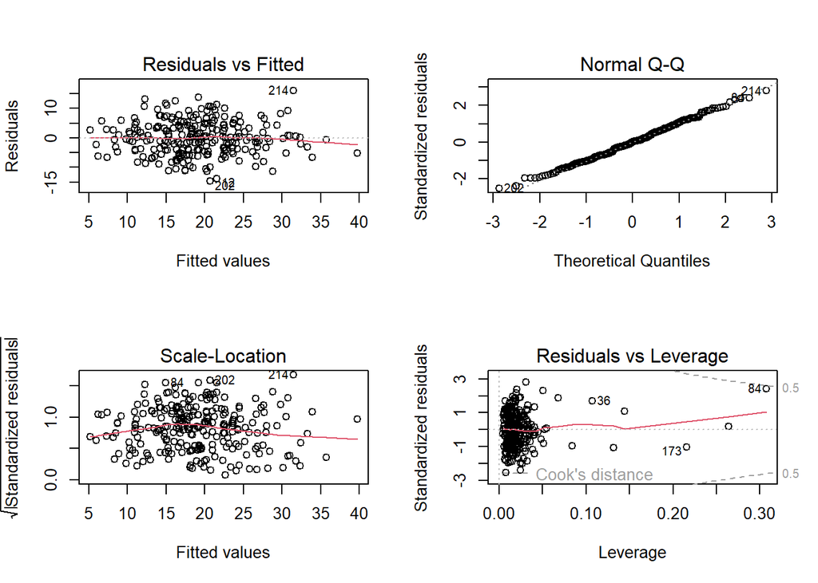

```r
par(mfrow = c(2,2))
plot(fit_mul)
```

Infatti ci si aspetta che i residui standardizzato seguano un distributzione normale standard e si più controllare velocemente se ci sono molti valori al di fuori dell’intervallo (-2,2), che pe runa normale standard dovrebbe contenere il $\approx$ 95% dei dati

Nel quarto grafico dei residui, che mostra il valore di leverage contro i residui, vediamo che c’è un punto che ha un valore grande di leverage e un residuo abbastanza grande: questi valori si riferiscono ad uno dei soggetti con un valore di `Ankle` particolarmente grande. Solo uno dei due soggetti viene evidenziato da questo grafico perché l’altro soggetto ha un valore di `Pct.BF` più in linea con la relazione generale.

Infine possiamo usare la distanza di Cook per individuare punti che abbiano una forte influenza sulla stima che si ottiene per i punti stessi: :

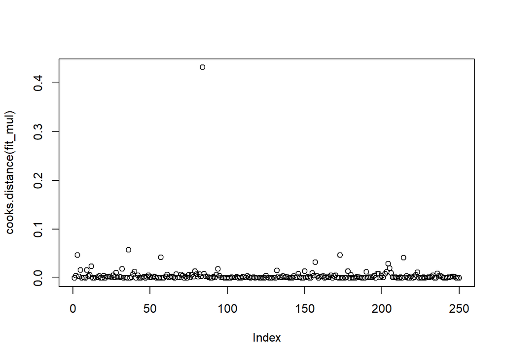

```r
i <- 84
ei <- bodyfat[i,"Pct.BF"] -
      predict(lm(formula = Pct.BF ~ Ankle + Weight + Age + Forearm + Hip, data = bodyfat, subset = -i),
              newdata = bodyfat[i,])
# (residuals(fit_mul)[i]^2*hatvalues(fit_mul)[i]/((1-hatvalues(fit_mul)[i])^2))*(1/length(coef(fit_mul)))
plot(cooks.distance(fit_mul))
```

Un grafico simile viene profdotto automaticamente da R con

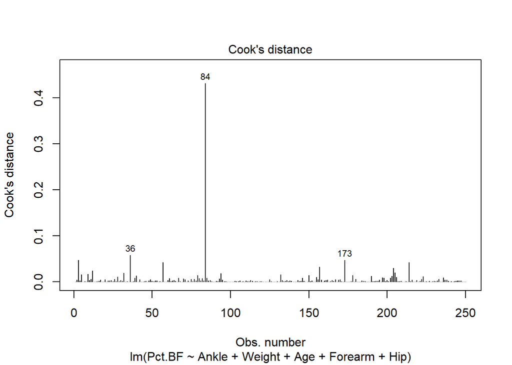

```r
plot(fit_mul, 4)
```

La distaza di Cook viene derivata con

```r
head((resid(fit_mul)^2)*(1/fit_mul$rank)*(hatvalues(fit_mul)/((1-hatvalues(fit_mul))^2))*(1/summary(fit_mul)$sigma^2))
```

```
##            1            2            3            4            5            6
## 4.482744e-04 4.474102e-03 4.723548e-02 2.951863e-03 1.601842e-02 2.589478e-06
```

```r
head(cooks.distance(fit_mul))
```

```
##            1            2            3            4            5            6
## 4.482744e-04 4.474102e-03 4.723548e-02 2.951863e-03 1.601842e-02 2.589478e-06
```

```r
# note compared to the slides R divides by summary(fit_mul)$sigma - no difference to the ranking of influential observations
```

In questo dataset è probabile che i valori abnormi che vediamo siano dovuti ad errori di trascrizione ed è ipotizzabile che le caviglie di questi soggetti misurino 23.9 e 23.7 e non 33.9 e 33.7cm

```r
bodyfat$Ankle[bodyfat$Ankle > 30]
```

```
## [1] 33.9 33.7
```

```r
bodyfat$Ankle[bodyfat$Ankle > 30] <- bodyfat$Ankle[bodyfat$Ankle > 30] - 10
```

Che effetto ha questo cambiamento sulle stime del modello

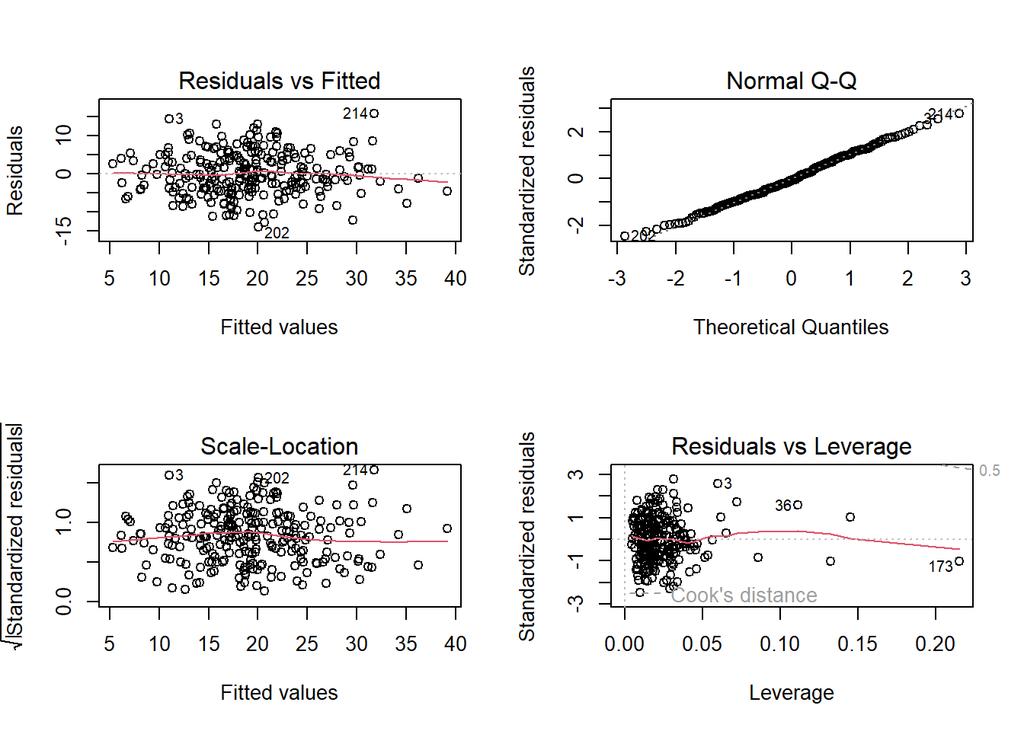

```r
fit_mul_corr <- lm(Pct.BF ~ Ankle + Weight + Age + Forearm + Hip, data = bodyfat)
par(mfrow=c(2,2))
plot(fit_mul_corr)
```

C’è ancora un punto con un valore di leverage un po’ alto ma niente di esagerato. Controllando invece le distanze di Cook

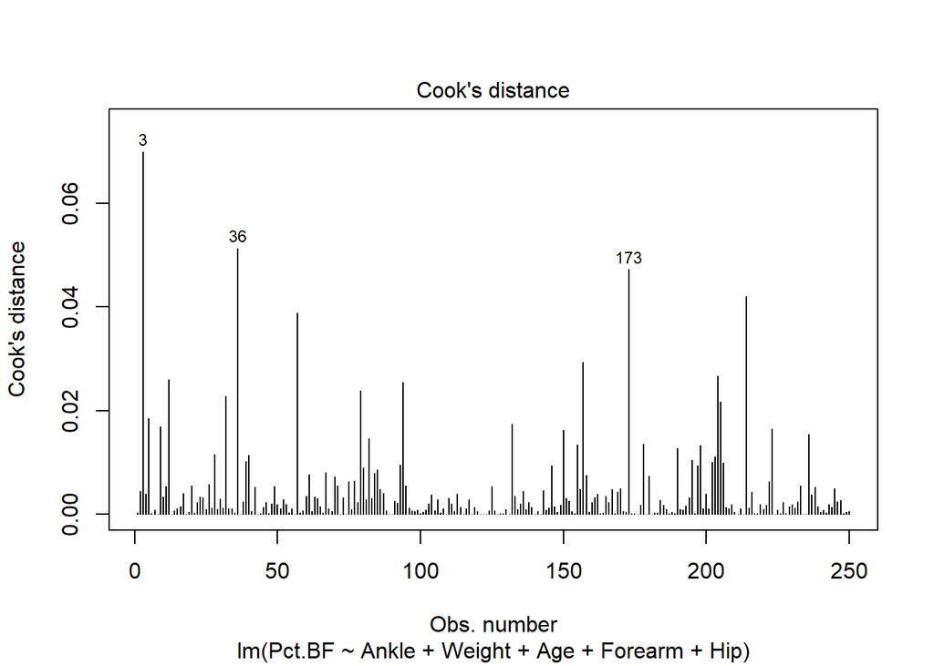

```r
plot(fit_mul_corr, which = 4)
```

non vediamo osservazioni smodatamente influenti.